# SMA-RILES

Pablo Busch

3/22/2022

# 1 Introduction

This document provides an analysis on the data for RILES (water emissions from Industrial Sources or “Residuos liquidos industriales”, available to download here [https://snifa.sma.gob.cl/DatosAbiertos]).

The data is reported at UF (Unidad Fiscalizable) level, which consist on the basic unit of the SMA (Superintendencia del Medio Ambiente) to identify common approved projects associated with the same company.

# 2 Data Exploration

The data contains the following columns of interest:

- Razon Social: “Nombre del titular de la fuente de emisión que reporta”. We have more than 40 companies in the zone of interest.
- Planta: “Nombre de la fuente de emisión que reporta”. A few sources have more than two plants, with different locations (lat/long).
- Punto de Descarga: Same as planta. “Nombre del punto de descarga de la fuente emisora”
- Norma: Always **D.S. 90.**
- Tipo de Control: Always **Autocontrol**
- Laboratorio: “Nombre del laboratorio que toma las muestras”. Around 8 different laboratories.
- UnidadFiscalizable: Cross to project data contained in other dataset: UF
- Parametro: “Parámetro contaminante reportado”
- Unidad: “Unidad del parámetro reportado”
- Valor reportado: “Emisión reportada”
- Caudal Muestra (m3/dia): Flow of the reported value of “muestra”.

Based on this information, it seems that we can compile monthly emissions at the level of **Planta**, which represent a point source where emissions occur to a water body.

## 2.1 Data conversion

As most parameters are measured as concentration in the sample (e.g. mg/L), we use the daily reported water flow measured in $m^3$/day to estimation monthly emissions as:

$$Montly \: Emissions = Daily \: Flow [\frac{m^3}{day}] * Concentration \:
normalized [\frac{kg}{m^3}]*Number \:of \: days$$

Where concentration normalized is simply the concentration expressed in terms of kg per $m^3$. Note, for parameters dimensionless, like T° or pH, we can only aim to report a weighted (by water flow) average per month.

# 3 Analysis

## 3.1 Number of projects with Water Emissions

| Region | Comuna | Pesca y Acuicultura | Instalación fabril | Minería | Saneamiento Ambiental |
| --- | --- | --- | --- | --- | --- |
| Región de la Araucanía | Cunco | 4 |  |  |  |
|  | Villarrica | 4 |  |  |  |
| Región de los Lagos | Llanquihue | 3 |  |  |  |
|  | Puerto Montt | 12 | 2 | 1 | 1 |
|  | Puerto Octay | 3 |  |  |  |
|  | Puerto Varas | 9 |  |  | 1 |
|  | Puyehue | 2 |  |  |  |
| Región de Los Ríos | Lago Ranco | 3 |  |  |  |
|  | Los Lagos | 3 |  |  |  |
|  | Panguipulli | 5 |  |  |  |
|  | Río Bueno | 1 |  |  |  |
| Total | - | 49 | 2 | 1 | 2 |

We observe that most of the projects with declared water emissions correspond to fishing and aquaculture. Lather in this document, a map is provided to see the location of each project.

## 3.2 Example: Nitrógeno Total Kjeldahl

Let’s estimate the water emissions for one parameter: Total Kjeldahl Nitrogen. As the same plant could have multiple samples we first take the average concentration and average water flow.

Let’s check at the total emissions for 2020:

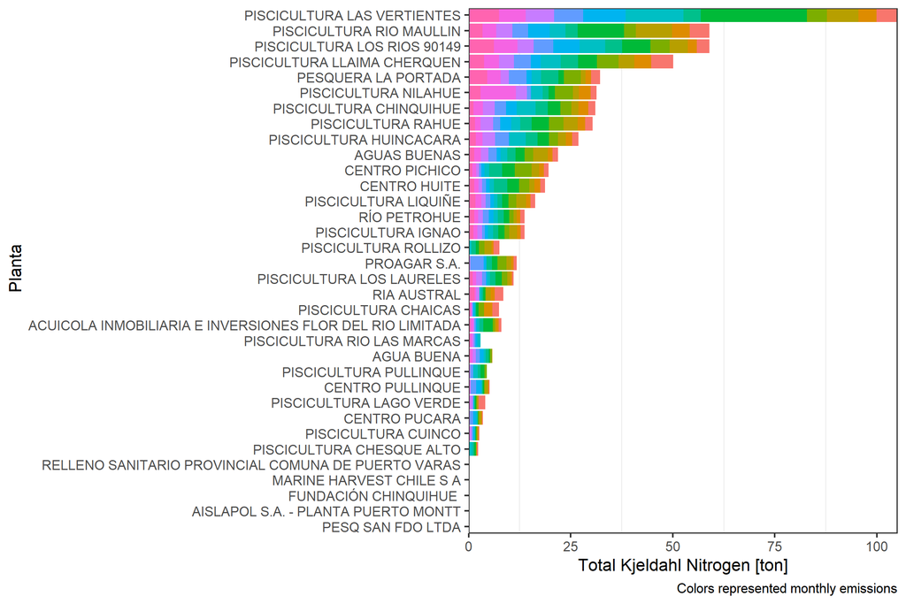

## 3.3 Map

First a map of all sources that have water emissions in the zone.

[interactive chart not shown]

Let’s look at a map with the emissions sources for Total Kjeldahl Nitrogen:

[interactive chart not shown]